# Fakultät für Physik

## Physikalisches Praktikum P2 für Studierende der Physik

Versuch P2-59, 60, 61 (Stand: April 2023)

[Raum F1-15](http://www-ekp.physik.uni-karlsruhe.de/~simonis/praktikum/layoutobjekte/Lageplan_P1.png)

Name: Schwarz Vorname: Felix E-Mail: unuhz@student.kit.edu

\begin{equation*} \begin{split} &\\ &\\ \end{split} \end{equation*}

Name: Steib Vorname: Lukas E-Mail: uzmpb@student.kit.edu

\begin{equation*} \begin{split} &\\ &\\ &\\ \end{split} \end{equation*}

Gruppennummer: Mo-21

\begin{equation*} \begin{split} &\\ &\\ &\\ \end{split} \end{equation*}

Betreuer: Jonathan Huschle

\begin{equation*} \begin{split} &\\ &\\ &\\ \end{split} \end{equation*}

Versuch durchgeführt am: 12.06.2023

**Beanstandungen:**

\begin{equation*} \begin{split} &\\ &\\ &\\ &\\ &\\ &\\ &\\ &\\ &\\ &\\ \end{split} %\text{\vspace{10cm}} \end{equation*}

Testiert am: __________________ Vermerk: __________________

# Operationsverstärker

## Motivation

Einfache elektrische Verstärkerschaltungen sind vielfach verwendete Hilfsmittel im physikalischen Labor. Jede:r Experimentalphysiker:in (und auch jPhysiklehrer:in) sollte in der Lage sein, Sie bei Bedarf rasch zu konzipieren und aufzubauen.

## Lernziele

Wir listen im Folgenden die wichtigsten **Lernziele** auf, die wir Ihnen mit dem Versuch **Operationsverstärker** vermitteln möchten:

- Sie lernen zwei Grundbausteine von Verstärkerschaltungen kennen: den Transistor und den Operationsverstärker. Im Vordergrund steht dabei die Anwendung dieser beiden Elemente in konkreten Schaltungen und nicht ihr "halbleiterphysikalisches Innenleben", das erst in späteren Vorlesungen behandelt werden wird. An dieser Stelle genügen zunächst einfache Modellvorstellungen.

## Versuchsaufbau

Im Folgenden sehen Sie den Arbeitsplatz an dem der Versuch durchegführt wird abgebildet: ([Link](https://git.scc.kit.edu/etp-lehre/p2-for-students/-/raw/main/Operationsverstaerker/figures/Operationsverstaerker.jpg))

[figure not shown]

Alle Schaltungen werden auf der abgebildeten Experimentier-Platine (*breed board*) aufgebaut. Es besteht aus vier Bereichen, die für verschiedene Aufgabenteile verwendet werden.

In der folgenden Abbilding sind die angegebenen Bereiche rot hervorgehoben: ([Link](https://git.scc.kit.edu/etp-lehre/p2-for-students/-/raw/main/Operationsverstaerker/figures/Experimentierboard.png))

[figure not shown]

## Durchführung

### Aufgabe 1: Emitterschaltung eines Transistors

Hierbei handelt es sich um die am häufigsten verwendete Transistorverstärkerschaltung. Verwenden Sie dafür aber hier nicht zuviel Zeit. Die Aufgaben zum Operationsverstärker (ab Aufgabe 2) sollten vorrangig erarbeitet werden.

#### Aufgabe 1.1

Bauen Sie auf der Experimentier-Platine den einstufigen gleichstromgegengekoppelten Transistorverstärker auf. Gehen Sie dabei durch die folgenden Punkte:

- Welche Funktionen haben die einzelnen Bauelemente, speziell $R_{e}$?
- Überprüfen Sie die Lage des Arbeitspunktes.
- Wozu dient der Kondensator $C_{e}$?
- Erläutern Sie Sinn und Wirkungsweise der Gegenkopplung.

**Lösung:**  
Bei allen folgenden Aufgaben ist auf dem Oszilloskop auf Channel 1 das Eingangssignal und auf Channel 2 das Ausgangssignal.  
Bei dem gleichstromgegengekoppelter Transistorverstärker wird mit einem Transistor das Eingangssignal verstärkt. Der Schaltplan sieht wiefolgt aus:

[figure not shown]

(https://git.scc.kit.edu/etp-lehre/p2-for-students/-/blob/main/Operationsverstaerker/Operationsverstaerker-Vorbereitungshilfe.pdf)  
Dies ist die aufgebaute Schaltung:

[figure not shown]

Das ausgegebene Signal am Oszilloskop ist in Aufgabe 1.2 dargestellt.  
Es wird eine Eingangsspannung von $60 \pm 4 mV$ angelegt.  
Der Verstärkungsfaktor des Transistors hängt von der Temperatur dieses Bauteils ab. Um dieses Problem zu beseitigen wird der Widerstand $R_e$ eingebaut.  
"Legt man nun am Eingang ein höheres Potential an, so fließt ein größerer Basisstrom und damit auch einen größerer Strom durch den Kollektor und den ”neuen“ Widerstand. An diesem Widerstand fällt hierdurch eine höhere Spannung ab, wodurch das Emitterpotential angehoben wird, was zu einer Absenkung der Spannungsdifferenz zwischen Basis und Emitter führt. Dies wirkt dem Anstieg des Ausgangsstroms entgegen ⇒ Stromgegenkopplung" (https://git.scc.kit.edu/etp-lehre/p2-for-students/-/blob/main/Operationsverstaerker/Operationsverstaerker-Vorbereitungshilfe.pdf)  
Der Kondensator $C_{e}$ leitet den Wechselstromanteil des Signals weiter und blockiert den Gleichstromanteil. Dadurch ist eine eine Wechselstromverstärkung möglich und es wird ausgeschlossen, dass der Arbeitspunkt durch den Emitterstrom beeinflusst wird.  
Die Gegenkopplung führt zu einer Stabilisation des Verstärkers. Das Ausgangssignal ist aber schwächer verstärkt. Die Gegenkopplung bringt einen Anteil des Ausgangssignals zu dem Emitter. Dadurch wird der Verstärker stabiler und schwächer.

#### Aufgabe 1.2

Führen Sie dem Verstärker als Eingangssignal eine Dreieckspannung mittlerer Frequenz (ca. $1\,\mathrm{kHz}$) zu, beobachten Sie oszilloskopisch das Ausgangssignal und bestimmen Sie die Verstärkung. Stellen Sie durch Variation der Amplitude des Eingangssignals verschiedene Ausgangsamplituden (etwa $3V_{SS}$ und $10V_{SS}$) ein und beurteilen Sie die Qualität des Verstärkers.

**Lösung:**  
Mit den gemessenen Spannungen für Eingangssignal und Ausgangssignal wird die Verstärkung des aufgebauten Verstärkers bestimmt.  
Die Unsicherheit der Werte kann abgelesen werden, da die Anzeige des Messgerätes um einen bestimmten Wert sichtbar schwankt.  
Folgendes Bild wird am Oszillosgraph für $3V_{SS}$ beobachtet:

[figure not shown]

Folgendes Bild wird am Oszillosgraph für $10V_{SS}$ beobachtet:

[figure not shown]

```python
import numpy as np
import matplotlib.pyplot as plt
from PhyPraKit import readPicoScope, resample
from scipy import signal
from scipy import interpolate
import sys
from kafe2 import  XYContainer, Fit, XYFit, Plot, ContoursProfiler
from uncertainties import ufloat, unumpy
from math import log10, floor
import scipy.integrate as integrate
import pandas as pd
import csv
```

```python
U_a_stromgleich1=np.array([3.04,10])
U_a_stromgleich1=unumpy.uarray(U_a_stromgleich1,[0.1,0.2])  #Unsicherheiten einfügen
U_e_stromgleich1=np.array([24.0,70.4])*10**(-3)
U_e_stromgleich1=unumpy.uarray(U_e_stromgleich1,[0.002,0.003])
Verstaerkung_stromgleich1=U_a_stromgleich1/U_e_stromgleich1
print('Die Verstärkung beträgt',Verstaerkung_stromgleich1[0],'sowie',Verstaerkung_stromgleich1[1])
```

```
Die Verstärkung beträgt 127+/-11 sowie 142+/-7
```

[output not shown]

Die Verstärkung ist sehr groß. Es ist aber eine große Abweichung der einzelnen Verstärkungen zueinander erkennbar. Daher ist die Qualität der Verstärkung nicht so gut. Bei verschiedenen Spannung ist eine große Variation der Verstärkung zu erkennen.

#### Aufgabe 1.3

Entfernen Sie den Emitterkondensator $C_{e}$. Beobachten Sie wieder das Ausgangssignal bei verschiedenen Amplituden und bestimmen Sie die Verstärkung dieses stromgegengekoppelten Verstärkers. Gehen Sie dabei durch die folgenden Punkte:

- Warum finden Sie gerade den Wert $R_{c}/R_{e}$ als Verstärkungsfaktor?
- Erklären Sie die Wirkungsweise der Gegenkopplung durch $R_{e}$ (stromgegengekoppelter Verstärker).

**Lösung:**

Es wird der Kondensator $C_e$ entfernt und wie bei Aufgabe 1.2 das Ein- und Ausgangssignal gemessen. Es werden als Spannungen $60 mV$, $120 mV$ und $180 mV$ angelegt.  
Für $60 mV$ wird folgendes am Oszillosgraph beobachtet:

[figure not shown]

Für $120 mV$ wird folgendes am Oszillosgraph beobachtet:

[figure not shown]

Für $180 mV$ wird folgendes am Oszillosgraph beobachtet:

[figure not shown]

Anschließend wird wieder die Verstärkung berechnet. Die Verstärkung wird mithilfe eines linearen Fits berechnet. Dabei ist die Steigung der Fitgeraden der Verstärkungsfaktor.

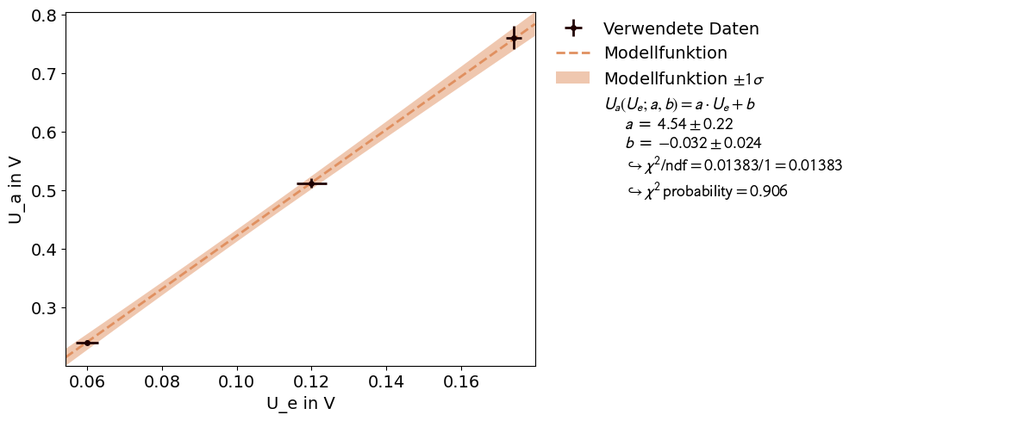

```python
U_a_strom1=np.array([240, 512, 760])*10**(-3)
U_a_strom1_err=np.array([4,8,20])*10**(-3)  #Unsicherheiten einfügen
U_e_strom1=np.array([60,120,174])*10**(-3)
U_e_strom1_err=np.array([3,4,2])*10**(-3)

x_error = U_e_strom1_err
y_error = U_a_strom1_err
xy_data = XYContainer(U_e_strom1,U_a_strom1)
def linear(x,a=0,b=0):
    return a*x+b
line_fit=Fit(data=xy_data,model_function=linear)
line_fit.add_error(axis='x', err_val=x_error,relative=False)  # add the x-error to the fit
line_fit.add_error(axis='y', err_val=y_error,relative=False)

line_fit.do_fit()
line_fit.assign_parameter_latex_names(x='U_e', a='a',b='b')
line_fit.assign_model_function_latex_name('U_a')
line_fit.assign_model_function_latex_expression('{a} \\cdot {x} + {b}')


line_fit.data_container.label = "Verwendete Daten"
line_fit.model_label = "Modellfunktion"

line_fit.data_container.axis_labels = ["U_e in V", "U_a in V"]
plot = Plot(fit_objects= line_fit)

plot.plot()
plt.show()
```

| U_A in mV | U_E in mV |
| --- | --- |
| 240 +/- 4 | 60 +/- 3 |
| 512 +/- 8 | 120 +/- 4 |
| 760 +/- 20 | 174 +/- 2 |

Die Spannungsverstärkung beträgt durch Berechung mit einem linearen Fit $4.54 \pm 0.22 $.
Die Verstärkung lässt sich auch theoretisch berechnen: $$v \approx \frac{R_C}{R_E}=\frac{470 \Omega}{100 \Omega}=4.7$$ Der theoretische Wert und der experimentelle Wert passen unter Berücksichtigung der Unsicherheit des experimentellen Wertes überein. Bei der Gegenkopplung wird über $R_e$ gegenphasig ein Teil der Ausgangsspannung zum Emitter gebracht. Dieser Anteil gleicht die Variationen des Transistors, die unteranderem durch verschiedene Temperaturen entstehen, aus. Dadurch ist das Ausgangssignal schwächer und stabiler.

#### Aufgabe 1.4

Bestimmen Sie die Verstärkung des strom- und gleichstromgegengekoppelten Verstärkers für verschiedene Frequenzen ($10,\:25,\:50,\:100\:\mathrm{und}\:500\,\mathrm{Hz}$ sowie $1,\:5,\:10,\:50\:\mathrm{und}\:100\,\mathrm{kHz}$). Besonders wichtig ist hierbei der Frequenzbereich $10\,\mathrm{Hz}$ bis $500\,\mathrm{Hz}$. Stellen Sie für beide Schaltungen den Verlauf der Verstärkung dar und erklären Sie ihn.

```
Die Verstärkung für gleichstromgegengekoppelter Verstärker beträgt: 9.7+/-1.0 , 19.0+/-1.4 , 30.7+/-1.8 , 45.3+/-3.1 , 127+/-6 , 147+/-7 , 167+/-6 , 163+/-9 , 167+/-9 , 163+/-11
Die Verstärkung für stromgegengekoppelter Verstärker beträgt: 1.33+/-0.09 , 1.88+/-0.12 , 2.66+/-0.23 , 3.75+/-0.28 , 4.33+/-0.33 , 4.33+/-0.33 , 4.17+/-0.32 , 4.17+/-0.32 , 4.17+/-0.32 , 4.17+/-0.32
```

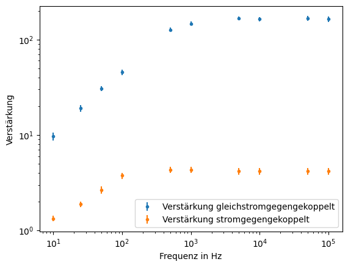

```python
f=np.array([10,25,50,100,500,1000,5000,10000,50000,100000]) #120mv stromgegen 60mv gleichstromgegen
U_a_stromgleich=np.array([580,1140,1840,2720,7600,8800,10000,9800,10000,9800])*10**(-3)
U_a_stromgleich_unsi=np.array([50,40,60,40,10,10,200,200,200,200])*10**(-3)  #Unsicherheiten einfügen
U_e_stromgleich=np.array([60,60,60,60,60,60,60,60,60,60])*10**(-3)
U_e_stromgleich_unsi=np.array([3,4,3,4,3,3,2,3,3,4])*10**(-3)
U_a_strom=np.array([160,240,340,480,520,520,500,500,500,500])*10**(-3)
U_a_strom_unsi=np.array([1,1,20,20,20,20,20,20,20,20])*10**(-3)
U_e_strom=np.array([120,128,128,128,120,120,120,120,120,120])*10**(-3)
U_e_strom_unsi=np.array([8,8,8,8,8,8,8,8,8,8])*10**(-3)
U_a_stromgleich_ges=unumpy.uarray(U_a_stromgleich,U_a_stromgleich_unsi)
U_e_stromgleich_ges=unumpy.uarray(U_e_stromgleich,U_e_stromgleich_unsi)
U_a_strom_ges=unumpy.uarray(U_a_strom,U_a_strom_unsi)
U_e_strom_ges=unumpy.uarray(U_e_strom,U_e_strom_unsi)
Verstaerkung_stromgleich_ges=U_a_stromgleich_ges/U_e_stromgleich_ges
Verstaerkung_strom_ges=U_a_strom_ges/U_e_strom_ges
print('Die Verstärkung für gleichstromgegengekoppelter Verstärker beträgt:',Verstaerkung_stromgleich_ges[0],',',Verstaerkung_stromgleich_ges[1],',',Verstaerkung_stromgleich_ges[2],',',Verstaerkung_stromgleich_ges[3],',',Verstaerkung_stromgleich_ges[4],',',Verstaerkung_stromgleich_ges[5],',',Verstaerkung_stromgleich_ges[6],',',Verstaerkung_stromgleich_ges[7],',',Verstaerkung_stromgleich_ges[8],',',Verstaerkung_stromgleich_ges[9])
print('Die Verstärkung für stromgegengekoppelter Verstärker beträgt:',Verstaerkung_strom_ges[0],',',Verstaerkung_strom_ges[1],',',Verstaerkung_strom_ges[2],',',Verstaerkung_strom_ges[3],',',Verstaerkung_strom_ges[4],',',Verstaerkung_strom_ges[5],',',Verstaerkung_strom_ges[6],',',Verstaerkung_strom_ges[7],',',Verstaerkung_strom_ges[8],',',Verstaerkung_strom_ges[9])

#plt.plot(f, unumpy.nominal_values(Verstaerkung_stromgleich_ges), color = 'pink', linestyle='None',marker='.',label='Verstärkung gleichstromgegengekoppelt')
#plt.plot(f, unumpy.nominal_values(Verstaerkung_strom_ges), color = 'darkblue', linestyle='None',marker='x',label='Verstärkung stromgegengekoppelt')
plt.errorbar(f, unumpy.nominal_values(Verstaerkung_stromgleich_ges), unumpy.std_devs(Verstaerkung_stromgleich_ges),fmt ='o',markersize=3,label='Verstärkung gleichstromgegengekoppelt')
plt.errorbar(f, unumpy.nominal_values(Verstaerkung_strom_ges), unumpy.std_devs(Verstaerkung_strom_ges),fmt ='o',markersize=3,label='Verstärkung stromgegengekoppelt')
plt.xlabel('Frequenz in Hz')
plt.ylabel('Verstärkung')
plt.yscale('log')
plt.xscale('log')
plt.legend()
plt.show()
```

gleichstromgegengekoppelter Verstärker (Schaltung von 1.2):

| Frequenz in Hz | U_A in V | U_E in V | Verstärkungsfaktor |
| --- | --- | --- | --- |
| 10 | 0.580 +/- 0.050 | 0.060 +/- 0.003 | 9.7 +/- 1.0 |
| 25 | 1.140 +/- 0.040 | 0.060 +/- 0.004 | 19.0 +/- 1.4 |
| 50 | 1.840 +/- 0.060 | 0.060 +/- 0.003 | 30.7 +/- 1.8 |
| 100 | 2.720 +/- 0.040 | 0.060 +/- 0.004 | 45.3 +/- 3.1 |
| 500 | 7.600 +/- 0.010 | 0.060 +/- 0.003 | 127 +/- 6 |
| 1000 | 8.800 +/- 0.010 | 0.060 +/- 0.003 | 147 +/- 7 |
| 5000 | 10.000 +/- 0.200 | 0.060 +/- 0.002 | 167 +/- 6 |
| 10000 | 9.800 +/- 0.200 | 0.060 +/- 0.003 | 163 +/- 9 |
| 50000 | 10.000 +/- 0.200 | 0.060 +/- 0.003 | 167 +/- 9 |
| 100000 | 9.800 +/- 0.200 | 0.060 +/- 0.004 | 163 +/- 11 |

stromgegengekoppelter Verstärker (Schaltung von 1.3):

| Frequenz in Hz | U_A in V | U_E in V | Verstärkungsfaktor |
| --- | --- | --- | --- |
| 10 | 0.160 +/- 0.001 | 0.120 +/- 0.008 | 1.33 +/- 0.09 |
| 25 | 0.240 +/- 0.001 | 0.128 +/- 0.008 | 1.88 +/- 0.12 |
| 50 | 0.340 +/- 0.020 | 0.128 +/- 0.008 | 2.66 +/- 0.23 |
| 100 | 0.480 +/- 0.020 | 0.128 +/- 0.008 | 3.75 +/- 0.28 |
| 500 | 0.520 +/- 0.020 | 0.120 +/- 0.008 | 4.33 +/- 0.33 |
| 1000 | 0.520 +/- 0.020 | 0.120 +/- 0.008 | 4.33 +/- 0.33 |
| 5000 | 0.500 +/- 0.020 | 0.120 +/- 0.008 | 4.17 +/- 0.32 |
| 10000 | 0.500 +/- 0.020 | 0.120 +/- 0.008 | 4.17 +/- 0.32 |
| 50000 | 0.500 +/- 0.020 | 0.120 +/- 0.008 | 4.17 +/- 0.32 |
| 100000 | 0.500 +/- 0.020 | 0.120 +/- 0.008 | 4.17 +/- 0.32 |

Die Gegenkopplung des Wechselstroms verringert die Verstärkung der stromgegengekoppelten Schaltung im Vergleich zur gleichstromgegengekoppelten Schaltung.

### Aufgabe 2: Grundschaltung eines Operationsverstärkers

#### Aufgabe 2.1

Bauen Sie auf der Experimentier-Platine mit einem Operationsverstärker einen nichtinvertierenden Verstärker mit etwa zehnfacher Verstärkung. Gehen Sie dabei durch die folgenden Punkte:

- Überprüfen Sie die Funktion der Schaltung.
- Führen Sie dem Eingang eine Dreieckspannung mittlerer Frequenz ($1\,\mathrm{kHz}$) zu und beobachten Sie oszilloskopisch das Ausgangssignal.
- Vergleichen Sie die experimentell und rechnerisch ermittelten Verstärkungsfaktoren.

**Lösung:**  
Der Schaltplan für einen nichtinvertierenden Verstärker sieht wiefolgt aus:

[figure not shown]

(https://git.scc.kit.edu/etp-lehre/p2-for-students/-/blob/main/Operationsverstaerker/Operationsverstaerker-Vorbereitungshilfe.pdf)  
Es wird folgendes Bild oszillographisch aufgezeichnet, dabei wird eine Frequenz von 1kHz und eine Eingangsspannung von $ 500 mV$ angelegt :

[figure not shown]

Es kann die Verstärkung $v$ mit der Formel $v=1+\frac{R_2}{R_1}$. Es wird ein Widerstand $R_1$ von $1 k\Omega$ und ein Widerstand $R_2$ von $10 k\Omega$ verwendet. Daher ist die bei dem nichtinvertierenden Verstärker die theoretische Verstärkung eine elffache Verstärkung.  
Die experimentell zu bestimmende Verstärkung lässt sich mit der Formel $v=\frac{U_A}{U_E}$ bestimmen.

```python
U_a=np.array([5.600])
U_a=unumpy.uarray(U_a,[0.200])  #Unsicherheiten einfügen
U_e=np.array([0.504])
U_e=unumpy.uarray(U_e,[0.008])
v=U_a/U_e
print('Für die gemessenen Werte ergeben sich folgende Verstärkungen: ',np.round(unumpy.nominal_values(v)[0],3),'+/-',np.round(unumpy.std_devs(v)[0],3))
```

```
Für die gemessenen Werte ergeben sich folgende Verstärkungen:  11.111 +/- 0.434
```

Es wurden folgende Werte gemessen:

[output not shown]

Der experimentell ermittelte Wert passt mit dem Literaturwert sehr gut überein.

#### Aufgabe 2.2

Demonstrieren Sie den hohen Eingangswiderstand und den kleinen Ausgangswiderstand dieser Schaltung mit Hilfe geeigneter Verfahren.

**Lösung:**  
Um den Eingangswiderstand zu bestimmen wird die Schaltung benötigt:

[figure not shown]

(https://git.scc.kit.edu/etp-lehre/p2-for-students/-/blob/main/Operationsverstaerker/Operationsverstaerker-Vorbereitungshilfe.pdf)  
Der Eingangswiderstand wird mit einem Vorwiderstand in Reihe geschalten.  
Der Eingangswiderstand $X$ kann nach dem Messen der Gesamtspannung $U_E$, dem Spannungsabfall $U_{R_{M}}$ und dem Widerstand $R_M$ von dem Vorwiderstand berechnet werden. Dazu wird die Formel $X=R_M \cdot \left(\frac{U_E}{U_{R_{M}}}-1\right)$ benutzt.  
Um den Ausgangswiderstand zu bestimmen wird die Schaltung benötigt:

[figure not shown]

(https://git.scc.kit.edu/etp-lehre/p2-for-students/-/blob/main/Operationsverstaerker/Operationsverstaerker-Vorbereitungshilfe.pdf)  
Den genauen Ausgangswiderstand zu bestimmen ist nicht einfach wegen internen "Nachreglungen". Grob kann der Wert aber durch ein Potentiometer parallel zum Ausgang bestimmt werden. Außerdem wird der Innenwiderstand solange veringert solange die Ausgangsspannung nicht abfällt.  
Zu dem Zeitpunkt, wenn das Ausgangssignal um die Hälfte abgenommen hat, kommt der Ausgangswiderstand ungefähr der aktuellen Einstellung des Potentiometers gleich.

```python
# Eingansimpendanzberechnung
R_m=ufloat(10000000,10)
U_e=ufloat(1.03,0.01)
U_r=ufloat(0.007,0.0002)
X=R_m*(U_e/U_r-1)
print('Der Eingangswiderstand beträgt',X,'\u03A9')
#Ausgangsimpedanz
U_0 = 11.8
R_aus  = 280
```

```
Der Eingangswiderstand beträgt (1.46+/-0.04)e+09 Ω
```

Mit den gemessenen Daten ergibt sich für den Eingangswiderstand:

[output not shown]

Für den Eingangswiderstand wird also ein Wert von $1.46\cdot 10^9 \pm 0.04\cdot 10^9 \Omega$ ermittelt. Für den Ausgangswiderstand wurde nach oben beschriebener Messmethode ein Widerstand von $280 \Omega$ ermittelt. Der Eingangswiderstand ist also etwa um den Faktor $5 \cdot 10^6$ größer als der Ausgangswiderstand, was die Näherung des unendlich hohen Einganswiderstand und dem nicht existenten Ausgangswiderstand plausibel erscheinen lässt.

#### Aufgabe 2.3

Bestimmen Sie die Verstärkung in Abhängigkeit von der Frequenz ($10\:\mathrm{und}\:100\,\mathrm{Hz}$ sowie $1,\:10,\:25,\:50,\:75\:\mathrm{und}\:100\,\mathrm{kHz}$). Gehen Sie dazu wie folgt vor:

- Wählen Sie als Eingangssignal eine Sinuswechselspannung mit einer Amplitude von $0,5V_{SS}$ und beobachten Sie das Ausgangssignal oszilloskopisch.
- Können Sie die bei hohen Frequenzen auftretenden Verzerrungen erklären?

**Lösung:**  
In diesem Versuchsteil wird die Auswirkung von verschiedenen Frequenzen auf die Verstärkung des Verstärkers bestimmt.  
Dabei wird der Spitze-Spitze-Wert der Ausgangs- und Eingangsspannung notiert. Es wird analog zu Aufgabe 1.4 vorgegangen.  
Der Verlauf der Verstärkung wird außerdem graphisch dargestellt.

```
Die Verstärkung für einen nichtinvertierenden Verstärker beträgt: 10.24+/-0.21 10.4+/-0.4 11+/-4 9.6+/-0.8 9.3+/-0.5 8.2+/-0.4 6.56+/-0.31 5.44+/-0.27
```

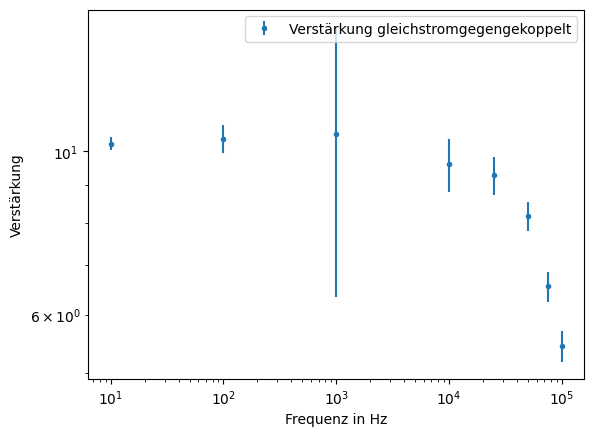

```python
f=np.array([10,100,1000,10000,25000,50000,75000,100000])
U_a_fre=np.array([5.12,5.2,5.28,4.8,4.64,4.08,3.28,2.72])
U_a_fre=unumpy.uarray(U_a_fre,[0.01,0.08,0.01,0.08,0.2,0.08,0.08,0.08])  #Unsicherheiten einfügen
U_e_fre=np.array([0.5,0.5,0.5,0.5,0.5,0.5,0.5,0.5])
U_e_fre=unumpy.uarray(U_e_fre,[0.01,0.02,0.2,0.04,0.02,0.02,0.02,0.02])
Verstaerkung_fre=U_a_fre/U_e_fre
print('Die Verstärkung für einen nichtinvertierenden Verstärker beträgt:',Verstaerkung_fre[0],Verstaerkung_fre[1],Verstaerkung_fre[2],Verstaerkung_fre[3],Verstaerkung_fre[4],Verstaerkung_fre[5],Verstaerkung_fre[6],Verstaerkung_fre[7])

plt.errorbar(f, unumpy.nominal_values(Verstaerkung_fre), unumpy.std_devs(Verstaerkung_fre),fmt ='o',markersize=3,label='Verstärkung gleichstromgegengekoppelt')
plt.legend()
plt.xlabel('Frequenz in Hz')
plt.ylabel('Verstärkung')
plt.yscale('log')
plt.xscale('log')
plt.show()
```

nichtinvertierender Verstärker (Schaltung von 2.1):

| Frequenz in Hz | U_A in V | U_E in V | Verstärkungsfaktor |
| --- | --- | --- | --- |
| 10 | 5.12 +/- 0.01 | 0.5 +/- 0.01 | 10.24 +/- 0.21 |
| 100 | 5.2 +/- 0.08 | 0.5 +/- 0.02 | 10.4 +/- 0.4 |
| 1000 | 5.28 +/- 0.01 | 0.5 +/- 0.2 | 11 +/- 4 |
| 10000 | 4.8 +/- 0.08 | 0.5 +/- 0.04 | 9.6 +/- 0.8 |
| 25000 | 4.64 +/- 0.2 | 0.5 +/- 0.02 | 9.3 +/- 0.5 |
| 50000 | 4.08 +/- 0.08 | 0.5 +/- 0.02 | 8.2 +/- 0.4 |
| 75000 | 3.28 +/- 0.08 | 0.5 +/- 0.02 | 6.56 +/- 0.31 |
| 100000 | 2.72 +/- 0.08 | 0.5 +/- 0.02 | 5.44 +/- 0.27 |

Bei größeren Frequenzen ist die Verstärkung des Operationsverstärkers nicht mehr ganz so effektiv, da die Gegenkopplung der Verstärkung entgegen wirkt. Dies tritt ab der Frequenz von ungefähr $ 50 kHz$ bei der hier verwendeten Schaltung auf.  
$\longrightarrow$ Bei hohen Frequenzen ist mit einer Verzerrung des Ausgangssignals zu rechnen.

### Aufgabe 3: Die invertierende Grundschaltung

Hierbei handelt es sich wohl die wichtigste Grundschaltung von Operationsverstärkern.

#### Aufgabe 3.1

Bauen Sie mit einem Operationsverstärker einen invertierenden Verstärker mit zehnfacher Verstärkung auf. Gehen Sie dabei durch die folgenden Punkte:

- Überprüfen Sie die Funktion und erklären Sie die Wirkungsweise der Schaltung.
- Leiten Sie die Verstärkung her.

**Lösung:** Schaltplan der invertierenden Grundschaltung:

[figure not shown]

(https://git.scc.kit.edu/etp-lehre/p2-for-students/-/blob/main/Operationsverstaerker/Operationsverstaerker-Vorbereitungshilfe.pdf)  
Die aufgebaute Schaltung sieht folgendermaßen aus:

[figure not shown]

Am Oszilloskop wird graphisch dargestellt:

[figure not shown]

Ein invertierender Verstärker wird aufgebaut mit einem Operationsverstärker (OPV) und einem Rückkopplungswiderstand, der die Eingangsspannung verstärkt und invertiert. Mit dem OPV wird die Differenzspannung zwischen den Eingängen null, da der OPV die Ausgangsspannung entsprechend anpasst wird. Durch den Eingangswiderstand geht der Eingangsstrom in den invertierenden Eingang des OPV. Die Größe des Rückkopplungswiderstands im Vergleich zum Eingangswiderstand bestimmt die Verstärkung des Verstärkers. Die Ausgangsspannung des invertierenden Verstärkers ist proportional zur Eingangsspannung, jedoch mit umgekehrtem Vorzeichen. Insgesamt ermöglicht der invertierende Verstärker die Inversion und Verstärkung der Eingangssignale.  
Die Verstärkung lässt sich folgendermaßen herleiten:

$$v_U = \frac{U_A}{U_E} = \frac{R_2 \cdot (-I)}{R_1 \cdot I} = -\frac{R_2}{R_1}$$

Für die verwendeten Widerstände $R_1 = 1 k\Omega$ und $R_2 = 10 k\Omega$ ergibt sich somit eine Verstärkung von $v_U = -10$.

```python
U_a = ufloat(4.80,0.08)
U_e = ufloat(0.5,0.02)
v =- U_a/U_e
print("Verstärkungsfaktor: ",v )
```

```
Verstärkungsfaktor:  -9.6+/-0.4
```

Die theoretische Verstärkung und die experimentell Bestimmte passen gut überein.

#### Aufgabe 3.2

Bauen Sie einen **Addierer** für zwei Eingangssignale auf. Als Eingangssignale können Sie eine Dreieck-, Rechteck- oder Sinusspannung (bis $1\,\mathrm{kHz}$) und eine mit den auf der Platine vorhandenen Potentiometern realisierbare regelbare Gleichspannungen im Bereich $-15\,\mathrm{V}$ bis $+15\,\mathrm{V}$ verwenden. Beobachten Sie die Ausgangsspannung oszilloskopisch. Schalten Sie dazu den Eingang des Oszilloskops auf „DC-Kopplung“, damit die Gleichspannung korrekt dargestellt wird. Diskutieren Sie Ihre Beobachtung.

**Lösung:**  
Schaltplan für den Addierer:

[figure not shown]

(https://git.scc.kit.edu/etp-lehre/p2-for-students/-/blob/main/Operationsverstaerker/Operationsverstaerker-Vorbereitungshilfe.pdf)
Die Schaltung kann durch eine Gleichung beschrieben werden: $$ U_A = R_2 \cdot I_2 = -R_2(I_{11}+I_{12})= -R_2 \cdot \left(\frac{U_{E1}}{R_{11}} + \frac{U_{E2}}{R_{12}}\right) $$ Für gleiche Widerstände wird das Signal addiert und negiert. Durch $R_{2}$ lässt sich das Signal verstärken oder abschwächen, durch eine Änderung von $R_{11}$ und $R_{12}$ die zu addierenden Signale gewichten.
Es wird eine $5 V$ Dreiecksspannung bei einer Frequenz von 1kHz benutzt.
Zuerst wird die Addition einer Gleichspannung, die minimal $-15 V$ beträgt, aber mit einem Potentiometer soweit abgeschwächt wird bis die Signale gut graphisch darstellbar sind, hier abgebildet:

[figure not shown]

Anschließend wird die Addition einer Gleichspannung, die maximal $15 V$ beträgt, aber mit einem Potentiometer soweit abgeschwächt wird bis die Signale gut graphisch darstellbar sind, hier abgebildet:

[figure not shown]

Da das Signal invertiert wird, liegt die erste Spannungskurve höher als die zweite.

#### Aufgabe 3.3

Bauen Sie einen **lntegrierer** auf. Schalten Sie das Oszilloskop wieder zurück auf „AC-Kopplung“. Verwenden Sie als Eingangssignal Rechteck- und Dreieckspannungen niedriger Frequenz (im Bereich $50\,\mathrm{Hz}$ bis $100\,\mathrm{Hz}$) und großer Amplitude. Gehen Sie dabei durch die folgenden Punkte:

- Beobachten Sie wieder oszilloskopisch.
- Erklären Sie die Wirkungsweise der Schaltung (ohne Berücksichtigung des Widerstandes $R_{s}$, der nur der Stabilisierung des Integrierers dient).

**Lösung:**

[figure not shown]

(https://git.scc.kit.edu/etp-lehre/p2-for-students/-/blob/main/Operationsverstaerker/Operationsverstaerker-Vorbereitungshilfe.pdf) Der Integrierer lässt sich erreichen, wenn bei dem Addierer der Kondensator durch einen Widerstand ausgestauscht wird. Der negative Eingang des Operationsverstärker ist geerdet, bzw. besitzt ein Potential von $0 V$. Der Kondensator sammelt die Ladung, die durch den Eingangsstrom fließt und verursacht eine Integration des Signals. Die Ausgangsspannung wird proportional zur zeitlichen Änderung der Eingangsspannung durch die Erdung. Der Integrierer erzeugt eine Ausgangsspannung, die von der zeitlichen Integration des Eingangssignals abhängt.  
Es wird eine Spannung von $1 V$ angelegt, eine Frequenz von $50 Hz$ benutzt.  
Es wird eine Sinusspannung integriert:

[figure not shown]

Es wird eine Dreiecksspannung integriert:

[figure not shown]

Das Integral einer Dreiecksspannung ist hierbei keine sinusförmige Welle, sondern wellenförmig aneinander gehängte Parabeln.  
Als letztes wird noch eine Rechteckspannung integriert:

[figure not shown]

#### Aufgabe 3.4

Bauen Sie einen **Differenzierer** auf. Gehen sie dabei durch die folgenden Punkte:

- Testen Sie die Funktion mit Rechteck- und Dreiecksignalen (im Bereich $50\,\mathrm{Hz}$ bis $500\,\mathrm{Hz}$).
- Erklären Sie die Wirkungsweise der Schaltung.

**Lösung:**  
"Durch Vertauschen des Widerstands und Kondensators beim Integrierer erhält man den Differenzierer:"

[figure not shown]

(https://git.scc.kit.edu/etp-lehre/p2-for-students/-/blob/main/Operationsverstaerker/Operationsverstaerker-Vorbereitungshilfe.pdf)  
Der Kondensator bewirkt, dass der Differenzierer die Eingangsspannung ableitet, indem er die Spannungsdifferenz über den Eingangswiderstand integriert und am Ausgang des OPV abgibt. Das resultierende Ausgangssignal ist proportional zur zeitlichen Ableitung der Eingangsspannung.  
Es wird wieder eine Frequenz von $50 Hz$ angenommen und eine Spannung von $1V$.  
Es werden wieder Bilder für alle 3 Wellenformen aufgenommen:

- Sinusspannung:

[figure not shown]

- Dreiecksspannung:

[figure not shown]

- Rechteckspannung:

[figure not shown]

### Aufgabe 4: Komplexere Schaltungen mit Operationsverstärkern

Im Folgenden werden nun einige etwas komplexere Schaltungen aufgebaut und untersucht. Welche der beiden Grundschaltungen erkennen Sie dabei amhäufigsten wieder?

#### Aufgabe 4.1

Bauen Sie mit einem Operationsverstärker einen idealen **Einweggleichrichter** auf und überprüfen Sie seine Funktion mit verschiedenen Eingangswechselspannungssignalen ($f<1\,\mathrm{kHz}$). Gehen Sie dabei durch die folgenden Punkte:

- Was sind die Vorteile dieser Schaltung gegenüber einer einfachen Gleichrichterschaltung mit einer Diode und einem Widerstand? Probieren Sie es aus!
- Wofür könnte ein solcher idealer Gleichrichter Verwendung finden?

**Lösung:** Nicht idealer Einweggleichrichter:

[figure not shown]

An diesem Gleichrichter können nur positive Anteile der Halbwelle die Diode passieren, somit können wir am Ausgang des Gleichrichters auch nur diese messen. Zudem fällt an der Diode eine Diodenknickspannung ab, sodass wir auch das positive Signal unter dieser Diodenknickspannung verlieren und somit die positive Halbwelle um diese Diodenknickspannung nach unten versetzen.  
Messung des nicht idealen Einweggleichrichters:

[figure not shown]

Es ist sichtbar, das nur ein Teil der oberen Halbwelle ausgegeben wird. Außerdem ist die Ausgabe verzerrt.

Idealer Einweggleichrichter:

[figure not shown]

Der ideale Gleichwegrichter benutzt einen Operationsverstärker, um diesen Spannungsabfall zu vermeiden. Desweiteren lassen sich die positive und negative Halbwelle als Ausgangssignal abgreifen. Das ursprüngliche Signal lässt sich verstärkt am Ausgang U_A abgreifen, allerdings ist durch die beiden Dioden zwischen den beiden Halbwellen ein Offset von zwei Mal der Diodenknickspannung sichtbar.

Messung der Ausgangsspannung U_A:

[figure not shown]

Hier ist sichtbar, das beide Halbwellen ausgegeben werden, allerdings mit einem deutlichen Offset zwischen ihnen.  
Messung der Halbwellenspannungen:

[figure not shown]

Hier ist sichtbar, das sich das Eingangssignal aus beiden Halbwellenspannungsausgängen perfekt rekonstruieren lässt, ohne das ein Offset durch eine Diode entsteht.

#### Aufgabe 4.2

Bauen Sie mit zwei Operationsverstärkern einen **Generator für Dreieck- und Rechtecksignale** auf. Erklären Sie die Funktionsweise der angegebenen Schaltung.

*Hinweis: Einer der Operationsverstärker arbeitet als Schwellenwertschalter, der andere als Integrierer.*

**Lösung:**  
Schaltplan des Generators:

[figure not shown]

Mit dieser Schaltung lässt sich aus einem Schmitt-Trigger (rechts) und einem Integrierer (links) ein Funktionsgenerator für Rechteck- und Dreiecksspannungen aus gegebener Gleichspannung konstruieren. Der Schmitt-Trigger erzeugt abhängig vom Vorzeichen des Eingangssignals eine konstante Spannung mit dem gleichen Vorzeichen in der Größe seiner Versorgungsspannung. Der Integrierer macht aus dieser konstanten Spannung eine steigende Spannung mit umgekehrtem Vorzeichen, und bringt den Schmitt-Trigger durch Rückkopplung des Ausgangs des Integrierers an den Eingang des Schmitt-Triggers zum umschalten. Durch diese Rückkopplung entsteht beim Schmitt-Trigger ein Rechtecksignal, und beim Integrierer ein Dreieckssignal.

Messung der Ausgangssignale:

[figure not shown]

Es ist deutlich sichtbar, das unsere Schaltung ein Rechteck- und Dreiecksignal ausgibt.

#### Aufgabe 4.3

Bauen Sie die so genannte **Programmierte Differentialgleichung 2. Ordnung** auf. Diese Generatorschaltung zur Erzeugung von Sinuswechselspannungen ermöglicht die Simulation einer Integralgleichung 2. Ordnung. Sie erkennen die beiden hintereinandergeschalteten Integrierer. Mit dem Potentiometer können Sie die Dämpfung der Schwingung einstellen. Die Schwingungsamplitude wächst an oder klingt ab, je nachdem ob Sie den Schleifer des Potentiometers aus der Mittelstellung nach rechts oder nach links gedreht haben.

Versuchen Sie, durch Variation des Potentiometerwiderstands die drei Fälle (Schwingfall, aperiodischer Grenzfall und Kriechfall) zu simulieren.

*Hinweis: Eine genaue Beschreibung dieser Schaltung finden Sie in "Tietze, Schenk: Halbleiterschaltungstechnik".*

**Lösung:**

Mit Operationsverstärken in integrierenden Schaltungen lassen sich aus Differentialgleichungen Schaltungen aufbauen, um deren Lösung am Ausgangssignal abzulesen. In diesem Fall wurde der klassische harmonische Oszillator in eine Schaltung übersetzt.

[figure not shown]

Diese Schaltung haben wir folgendermaßen aufgebaut:

[figure not shown]

Mit dem regelbarem Widerstand am Potentiometer ist es möglich die Dämpfung des harmonischen Oszillators zu variieren. Damit lassen sich die Fälle der starken, mittleren und schwachen Dämpfung darstellen.

stark:

[figure not shown]

mittel:

[figure not shown]

schwach:

[figure not shown]

\

Tauscht man zusätzlich den 1 MOhm Widerstand am Potentiometer durch einen 6,8kOhm Widerstand aus und passt den Widerstand durch den Potentiometer passen an, lässt sich auch der aperiodische Grenzfall erreichen.

[figure not shown]

Somit können mit dieser Schaltung alle typischen Verhalten des klassischen harmonischen Oszillators ausgegeben werden.